# R01

**Basics of Plotting with Numpy and Matplotlib**

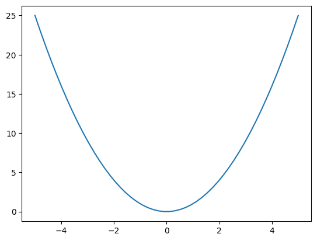

```python
import numpy as np
import matplotlib.pyplot as plt

# define time
t = np.linspace(-5,5)

# define the function
x = t**2

# plot the results
plt.plot(t,x)
plt.show()
```

**Questions for Checkoff:**

**Question 1:** Determine the period (in seconds) and the frequency in (in both Hertz and radians per second) by hand and then create plots in Jupyter Notebook that validate your answers.

- cos (7*t* − 0.5)
- cos (12*π**t* − *π*/4)

**Question 2:** Express the following as sums of complex exponentials. Validate your answers by plotting in Jupyter Notebook.

- 4cos (5*π**t* − *π*/5)
- 3cos (2*π**t* + *π*/7)

**Question 3:** Convert the following signals to cosines by hand, and validate your answers by plotting in Jupyter Notebook.

- (1 − 2*j*)*e*<sup>*j*3*t*</sup> + (1 + 2*j*)*e*<sup>− *j*3*t*</sup>
- 4*e*<sup>− *j*5*π**t*</sup> + 4*e*<sup>*j*5*π**t*</sup>

**Question 4:** Determine or estimate the equation of this function equation. Validate your answer by trying to recreate the plot in Jupyter.

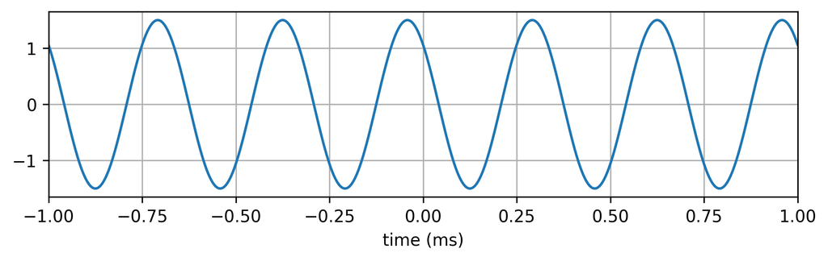

**Question 5:** Which of the following functions is most likely the plot of cos (2*t*)? Why?

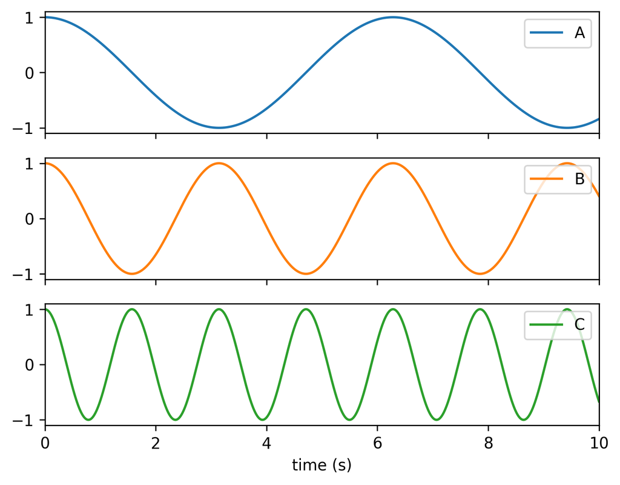

**Question 6:** Use your ADALM2000 board to generate sines, square, waves, and triangle waves, and play them out through your speaker. How do they sound the same? How do they *not* sound the same? Connect the signals to the ADALM oscilloscope and look at the signal FFTs. Comment on what makes them similar and/or different.